# 第10講 推定

確率分布を特徴づけるパラメタを推測する

Published

June 19, 2026

## 準備

以下で利用する共通パッケージを読み込む．

```r
library(conflicted)  # 関数名の衝突を警告
conflicts_prefer(    # 優先的に使う関数を指定
    dplyr::filter(),
    dplyr::select(),
    dplyr::lag(),
    )
library(tidyverse)
#' 日本語を用いるので macOS ではフォントの設定を行う
if(Sys.info()["sysname"] == "Darwin") { # macOS か調べて日本語フォントを指定
    theme_update(text = element_text(family = "HiraginoSans-W4"))
    update_geom_defaults("text", list(family = theme_get()$text$family))
    update_geom_defaults("label", list(family = theme_get()$text$family))}
```

## 一様分布の平均の推定

### 問題

$X$ を一様乱数に従う確率変数とし，平均値の推定量として以下を考える． それぞれの推定量の分散を比較しなさい．

- 標本平均 (mean)
- 中央値 (median)
- 最大値と最小値の平均 ((max+min)/2)

#### ヒント

以下のような関数を作り，確率シミュレーションを行えばよい．

```r
estimate_means <- function(n, min, max){ # 観測データ数
    x <- runif(n, min = min, max = max)  # 一様乱数を生成，範囲は引数から
    return(c(xbar = mean(x),
             med = median(x),
             mid = (max(x)+min(x))/2))
} # 3つまとめて計算する関数
```

### 解答例

平均値の推定を行う関数(標本平均，中央値，最大最小の平均)を定義する．

```r
estimate_means <- function(n, min, max){
    x <- runif(n, min = min, max = max)
    return(c(xbar = mean(x),           # 標本平均
             med = median(x),          # 中央値
             mid = (max(x)+min(x))/2)) # 最大最小の平均
}
```

実験の設定を宣言する．

```r
n <- 10         # 観測データのサンプル数
mc <- 10000     # 実験回数
a <- 0; b <- 50 # 一様乱数の区間
```

確率シミュレーションを行う．

```r
mc_data <-
    replicate(mc, estimate_means(n, min = a, max = b)) |> # 3 x mc 型行列
    t() |>      # 転置して mc x 3 型行列に変換
    as_tibble() # データフレーム化
print(mc_data)  # 実験結果の一部を確認
```

```
# A tibble: 10,000 × 3
    xbar   med   mid
   <dbl> <dbl> <dbl>
 1  18.8  16.2  24.2
 2  17.7  11.5  24.7
 3  23.1  23.5  25.5
 4  24.3  23.2  26.0
 5  19.1  14.8  25.0
 6  24.9  29.8  21.8
 7  27.1  28.8  26.7
 8  22.8  27.7  23.0
 9  24.2  23.6  25.7
10  33.9  36.1  31.8
# ℹ 9,990 more rows
```

それぞれの推定量の平均と分散を計算し，結果を集計する．

```r
mc_data |>
    summarize(across(everything(),
                     list(mean = mean, var = var)))
```

```
# A tibble: 1 × 6
  xbar_mean xbar_var med_mean med_var mid_mean mid_var
      <dbl>    <dbl>    <dbl>   <dbl>    <dbl>   <dbl>
1      25.0     21.0     25.0    47.6     25.0    9.36
```

別々のヒストグラムにして比較してみる．

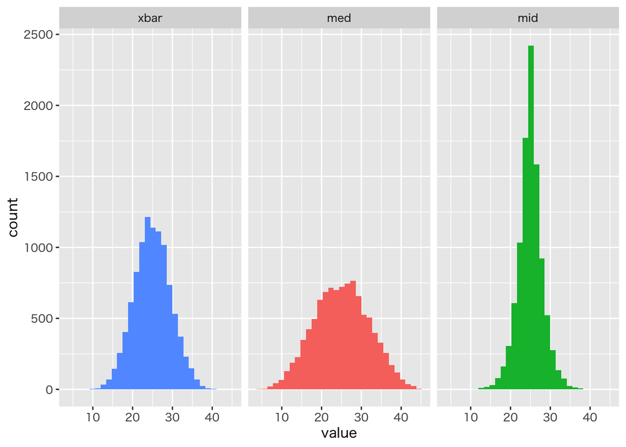

```r
mc_data |>
    pivot_longer(everything()) |>
    ggplot(aes(x = value)) +
    geom_histogram(aes(fill = name),
                   show.legend = FALSE) + # 凡例を表示しない
    facet_wrap(vars(as_factor(name)))     # 登場順に横に並べる
```

一様分布においては，最大最小の平均が良い推定量であることがわかる．

分位点を使ってもう少し詳しくみてみる．

```r
mc_data |> summary() # 四分位点を表示 (簡便な方法)
```

```
      xbar             med              mid
 Min.   : 9.445   Min.   : 4.318   Min.   :11.25
 1st Qu.:21.861   1st Qu.:20.093   1st Qu.:23.31
 Median :24.916   Median :25.051   Median :24.99
 Mean   :24.969   Mean   :25.024   Mean   :24.98
 3rd Qu.:28.061   3rd Qu.:29.819   3rd Qu.:26.65
 Max.   :40.656   Max.   :44.534   Max.   :37.69
```

```r
mc_data |> # データフレームとして取得する方法 (以下は一例)
    pivot_longer(everything()) |> # long format に変更
    group_by(name) |> # 推定量ごとに集計
    summarize(as_tibble_row(quantile(value))) # 計算結果を行に並べる
```

```
# A tibble: 3 × 6
  name   `0%` `25%` `50%` `75%` `100%`
  <chr> <dbl> <dbl> <dbl> <dbl>  <dbl>
1 med    4.32  20.1  25.1  29.8   44.5
2 mid   11.3   23.3  25.0  26.6   37.7
3 xbar   9.44  21.9  24.9  28.1   40.7
```

```r
mc_data |> # 別形式のデータフレームの作成例
    pivot_longer(everything()) |> # long format に変更
    group_by(name) |> # 推定量ごとに集計
    reframe(qs=quantile(value), probs=seq(0,1,.25))
```

```
# A tibble: 15 × 3
   name     qs probs
   <chr> <dbl> <dbl>
 1 med    4.32  0
 2 med   20.1   0.25
 3 med   25.1   0.5
 4 med   29.8   0.75
 5 med   44.5   1
 6 mid   11.3   0
 7 mid   23.3   0.25
 8 mid   25.0   0.5
 9 mid   26.6   0.75
10 mid   37.7   1
11 xbar   9.44  0
12 xbar  21.9   0.25
13 xbar  24.9   0.5
14 xbar  28.1   0.75
15 xbar  40.7   1
```

それぞれのヒストグラムを描くこともできる．

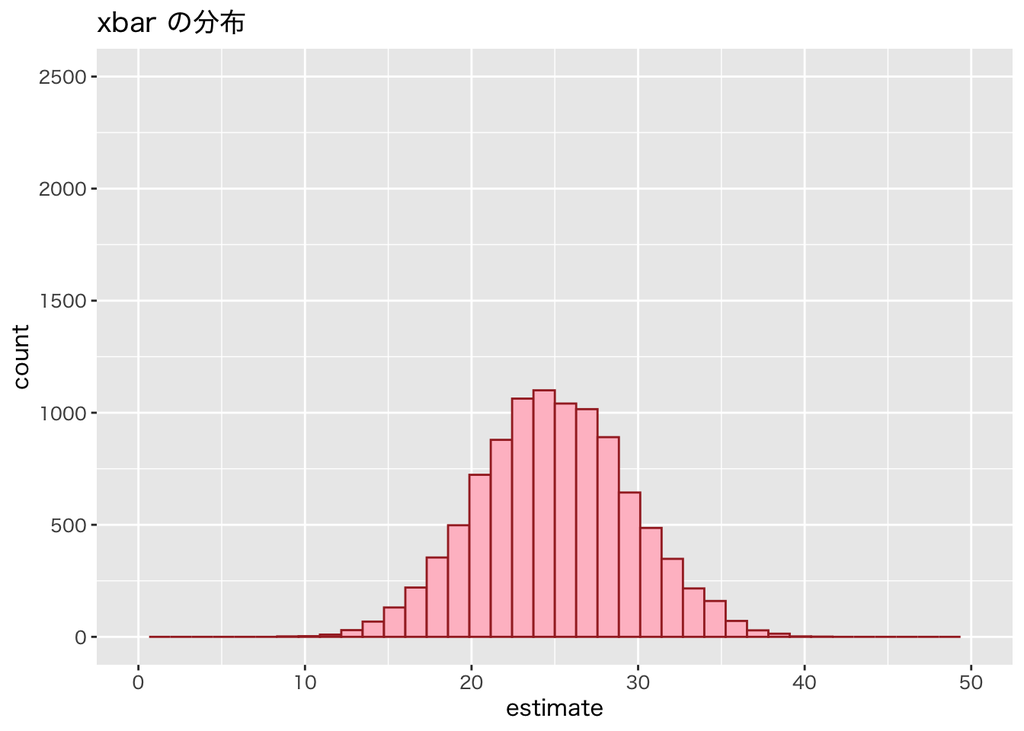

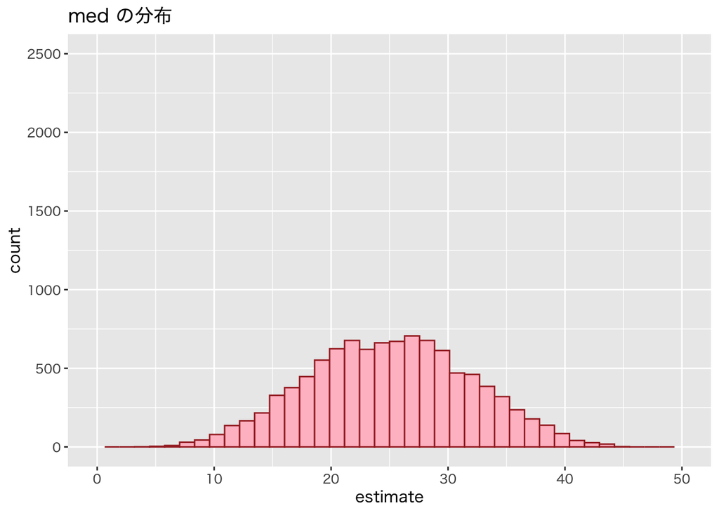

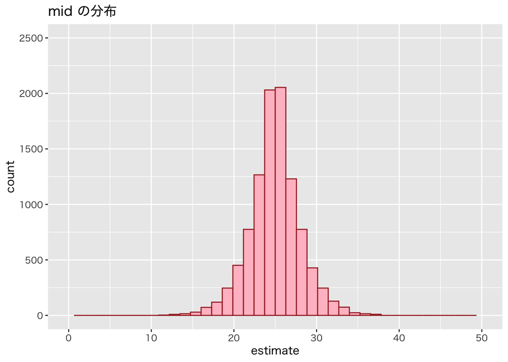

```r
for(name in c("xbar","med","mid")) {
    gg <-
        mc_data |>
        ggplot(aes(x = !!sym(name))) +
        geom_histogram(bins = 40,
                       fill = "pink",
                       colour = "brown") +
        lims(x = c(a,b), y = c(0,2500)) + # 同じ大きさの図にする
        labs(x = "estimate",
             title = paste(name, "の分布"))
    print(gg)
}
```

違う分布で試してみる．

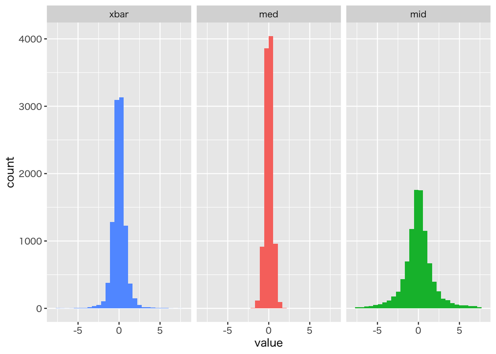

```r
estimate_means2 <- function(n){
    x <- rt(n, df = 2) # 自由度2のt分布 (裾が重く平均が推定しにくい分布)
    return(c(xbar = mean(x),
             med = median(x),
             mid = (max(x)+min(x))/2))
}
mc_data2 <-
    replicate(mc, estimate_means2(n)) |> t() |> as_tibble()
#' それぞれの分布を書いてみる
mc_data2 |>
    pivot_longer(everything()) |>
    ggplot(aes(x = value)) +
    geom_histogram(aes(fill = name),
                   show.legend = FALSE) +
    xlim(-8,8) +                          # x軸を調整する
    facet_wrap(vars(as_factor(name)))
```

この分布では中央値が良い推定量となることがわかる．

**Tip**

Rで用いることのできる色の名前は関数 colors()/colours() で確認することができる. 例えば以下のようにすると視覚的に確認することができる.

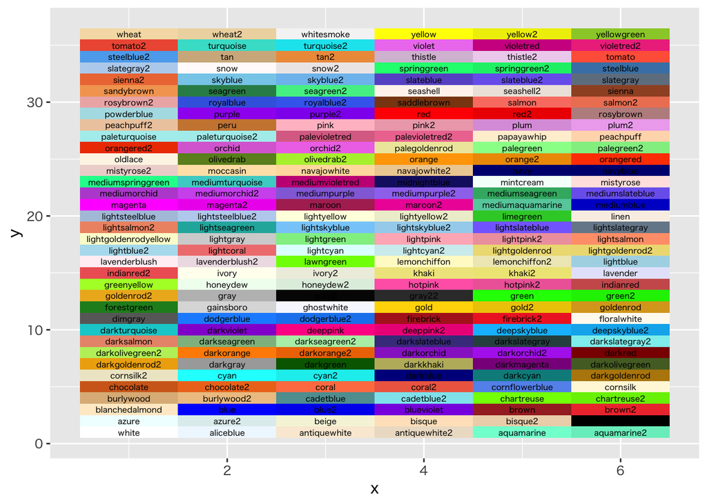

```r
cols <- colors()[grep("(grey|[0-1,3-9])",  # greyおよび2以外の数を含む色を排除
                      colors(),
                      invert = TRUE)]
ncols <- 6
nrows <- ceiling(length(cols)/ncols)       # 必要なタイルの枚数の計算
tibble(x = rep(1:ncols, nrows),
       y = rep(1:nrows, each = ncols),
       z = factor(1:(nrows*ncols))) |>     # タイルの配置のためのデータフレーム
    slice_head(n = length(cols)) |>        # 必要な行のみ残す
    ggplot(aes(x = x, y = y, fill = z)) +
    scale_fill_manual(values = cols) +     # fillの色を指定
    geom_tile(show.legend = FALSE) +       # 色のタイルを配置
    geom_text(aes(label = cols), size = 2) # 色名を記入
```

## ガンマ分布による風速データのモデル化

### 問題

東京都の気候データ (`tokyo_weather.csv`) の風速 (`wind`) の項目について以下の問に答えよ．

- 全データを用いてヒストグラム(密度)を作成しなさい．
- ガンマ分布でモデル化して最尤推定を行いなさい．
- 推定した結果をヒストグラムに描き加えて比較しなさい．
- 余力のある者は，自身で収集したデータを用いてモデル化と最尤推定を試みよ．

#### ヒント

ガンマ分布の最尤推定量は以下のようにして作成できる

```r
library("stats4") # 関数mleを利用するため
#' 数値最適化のためには尤度関数を最初に評価する初期値が必要
mle.gamma <- function(x, # 観測データ
                      nu0 = 1, alpha0 = 1){ # nu, alphaの初期値
    ## 負の対数尤度関数を定義 (最小化を考えるため)
    ll <- function(nu, alpha) # nuとalphaの関数として定義
        suppressWarnings(-sum(dgamma(x, nu, alpha, log = TRUE)))
    ## suppressWarnings は定義域外で評価された際の警告を表示させない
    ## 最尤推定(負の尤度の最小化)
    est <- mle(minuslogl = ll,                         # 負の対数尤度関数
               start = list(nu = nu0, alpha = alpha0), # 初期値
               method = "BFGS",                        # 最適化方法 (選択可能)
               nobs = length(x))                       # 観測データ数
    return(coef(est)) # 推定値のみ返す
}
```

### 解答例

データを読み込む．

```r
tw_data <- read_csv("data/tokyo_weather.csv")
```

風速データのヒストグラムを描く．

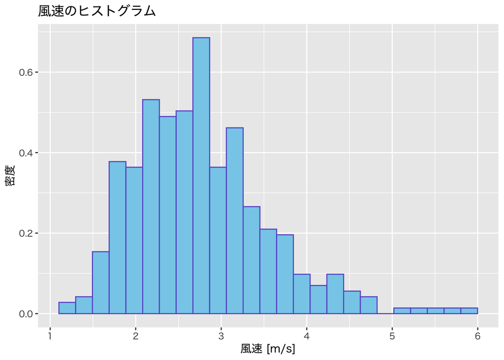

```r
tw_data |>
    ggplot(aes(x = wind)) +
    geom_histogram(aes(y = after_stat(density)), # 密度表示
                   bins = 25,                    # ビンの数の指定
                   fill = "skyblue",
                   colour = "slateblue") +
    labs(x = "風速 [m/s]", y = "密度", title = "風速のヒストグラム")
```

ガンマ分布の最尤推定量を求めるための関数を作成する．

```r
library("stats4")              # 関数mleを利用
mle.gamma <-
    function(x,                # 観測データ
             nu0 = 1,          # nu (shape) の初期値
             alpha0 = 1,       # alpha (rate) の初期値
             verbose = FALSE){ # debug用に追加
        ## 負の対数尤度関数の定義
        ll <-
            function(nu, alpha) # nuとalphaの関数として定義
                suppressWarnings( # 定義域外で評価された際の警告を表示させない
                    -sum(dgamma(x,
                                shape = nu,
                                rate = alpha,
                                log = TRUE))) # 対数密度
        ## 最尤推定(負の尤度の最小化)の実行
        est <- mle(minuslogl = ll,               # 負の対数尤度関数
                   start = list(nu = nu0,        # 初期値
                                alpha = alpha0),
                   method = "BFGS",              # 最適化方法 (選択可能)
                   nobs = length(x))             # 観測データ数
        ## 返値の処理
        if(verbose) {
            return(est)       # verbose=TRUEならmleの結果を全て返す
        } else {
            return(coef(est)) # 推定値のみ返す
        }
    }
```

最尤推定を行う．

```r
theta <-
    tw_data |>
    with(mle.gamma(wind)) # データフレームの列名を関数に渡す
print(theta)
```

```
       nu     alpha
12.624666  4.608925
```

得られた結果を前出のヒストグラム上に重ね描きする．

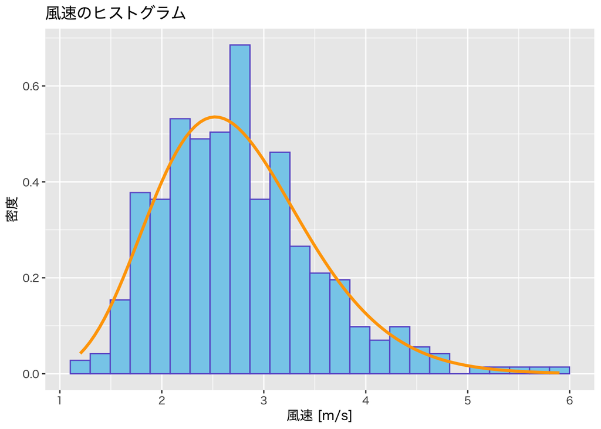

```r
last_plot() +
    geom_function(fun = dgamma,
                  args = list(shape = theta[1],
                              rate = theta[2]),
                  colour = "orange",
                  linewidth = 1.2)
```

シミュレーションにより推定量の良さの検証(一致性や不偏性の確認)を行うと以下のようになる．

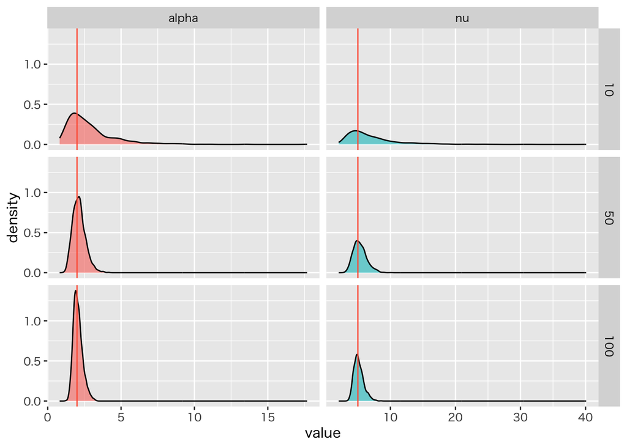

```r
set.seed(5678)      # 乱数のシード値の指定 (変更して再現性を確認してみよ)
nu <- 5; alpha <- 2 # 真のパラメタ
grand_truth <-      # 真のパラメタのデータフレーム
    tibble(nu,alpha) |>
    pivot_longer(everything())
mc <- 1000          # 実験回数 (計算が重いので少なめにしている)
#' Monte-Carlo実験
mc_data <-
    tibble(n = rep(c(10,50,100), each = mc)) |>    # 実験設定(データ数)のデータフレーム
    rowwise() |>                                   # 各行ごとに次の処理を実行
    mutate(est = list(as_tibble_row(               # 実験結果をtibble型式に変換して保存
               mle.gamma(rgamma(n,nu,alpha))))) |>
    unnest(est)                                    # リストを展開して通常のデータフレームに変換
mc_data |>
    mutate(n = as_factor(n)) |>                    # 実験設定を因子化して整理
    pivot_longer(!n) |>
    ggplot(aes(x = value, fill = name)) +          # nu/alphaごとに密度を推定
    geom_density(alpha = 0.6,
                 show.legend = FALSE) +
    geom_vline(data = grand_truth,                 # 真値の表示
               aes(xintercept = value),
               colour = "tomato") +
    facet_grid(rows = vars(n), cols = vars(name),  # nu/alpha およびデータ数ごとにグラフを表示
               scales = "free_x")                    # 座標軸は各列で適宜合わせる
```

個別に描く場合は，例えば以下のようにすればよい．

```r
for(n in c(10, 50, 100)){ # データ数を変えて実験
    ## Monte-Carlo実験
    mc_data <- # 推定値のデータフレーム
        replicate(mc, mle.gamma(rgamma(n, nu, alpha))) |>
        t() |> as_tibble()
    ## 結果を密度推定で表示
    gg <-
        mc_data |>
        ggplot(aes(x = nu)) + # nu の推定値の分布
        geom_density(fill = "skyblue1",
                     colour = "skyblue4") +
        geom_vline(xintercept = nu, # nu の真値
                   colour = "tomato",
                   linewidth = 1.2) +
        xlim(0,20) +
        labs(x = expression(nu), title = paste("n =",n))
    print(gg)
    gg <-
        mc_data |>
        ggplot(aes(x = alpha)) + # alpha の推定値の分布
        geom_density(fill = "seagreen1",
                     colour = "seagreen4") +
        geom_vline(xintercept = alpha, # alpha の真値
                   colour = "tomato",
                   linewidth = 1.2) +
        xlim(0,10) +
        labs(x = expression(alpha), title = paste("n =",n))
    print(gg)
}
```

## 日射量データの区間推定

### 問題

東京都の気候データ (`tokyo_weather.csv`) の日射量 (`solar`) の項目について以下の問に答えよ．

- 全データによる平均値を計算しなさい．
- ランダムに抽出した50点を用いて，平均値の0.9(90%)信頼区間を求めなさい．
- 上記の推定を100回繰り返した際，真の値(全データによる平均値)が信頼区間に何回含まれるか確認しなさい．
- 余力のある者は，自身で収集したデータで区間推定を試みよ．

### 解答例

全データによる平均値の計算を行う．

```r
mu <-
    tw_data |>
    pull(solar) |>
    mean()         # 真値(全データによる平均値)
print(mu)
```

```
[1] 14.28529
```

これを真値として信頼区間の精度の検証を行う．

ランダムに選んだデータ50点を用いて90%信頼区間を構成する．

```r
set.seed(1357) # 乱数のシード値の指定 (変更して再現性を確認してみよ)
n <- 50
#' 平均と標準偏差の推定を行う
est <-
    tw_data |>
    slice_sample(n = n) |>            # ランダムにn個取り出す
    summarize(across(solar,
                     list(mean = mean, sd = sd)))
xbar  <- est[["solar_mean"]]          # 標本平均
sigma <- est[["solar_sd"]]            # 標本標準偏差
z95 <- qnorm(0.95)                    # 標準正規分布の0.95分位点
(ci <- c(L = xbar-z95*sigma/sqrt(n),
         U = xbar+z95*sigma/sqrt(n))) # 信頼区間
```

```
       L        U
14.30956 17.84124
```

これを複数回行い，信頼区間の正答率を評価する．

```r
mc <- 100
mc_trial <- function(n){ # nを変えて実験できるように
    est <- tw_data |> slice_sample(n = n) |>
        summarize(across(solar, list(mean = mean, sd = sd)))
    xbar  <- est[["solar_mean"]]          # 標本平均
    sigma <- est[["solar_sd"]]            # 標本標準偏差
    return(c(L = xbar-z95*sigma/sqrt(n),
             U = xbar+z95*sigma/sqrt(n))) # 信頼区間
}
#' 信頼区間のMonte-Carlo実験
mc_data <-
    replicate(mc, mc_trial(n)) |>
    t() |> as_tibble() |>
    mutate(flag = L < mu & mu < U) # 真値が信頼区間に含まれるか
print(mc_data)                     # 実験結果を見る
```

```
# A tibble: 100 × 3
       L     U flag
   <dbl> <dbl> <lgl>
 1  11.9  15.5 TRUE
 2  12.9  16.7 TRUE
 3  12.6  16.5 TRUE
 4  11.6  14.6 TRUE
 5  11.5  15.0 TRUE
 6  13.3  17.1 TRUE
 7  13.7  17.3 TRUE
 8  11.7  15.3 TRUE
 9  13.1  16.2 TRUE
10  13.0  16.0 TRUE
# ℹ 90 more rows
```

```r
mc_data |> count(flag)             # 頻度を見る
```

```
# A tibble: 2 × 2
  flag      n
  <lgl> <int>
1 FALSE     6
2 TRUE     94
```

信頼区間について更に多数で評価してみる．

```r
mc <- 2000
mc_data <- # 信頼区間のMonte-Carlo実験
    replicate(mc, mc_trial(n)) |> t() |> as_tibble() |>
    mutate(flag = L < mu & mu < U)
mc_data |>
    count(flag) |>          # 正否の頻度を見る
    mutate(prob = n/sum(n)) # 確率を見る
```

```
# A tibble: 2 × 3
  flag      n   prob
  <lgl> <int>  <dbl>
1 FALSE   153 0.0765
2 TRUE   1847 0.924
```

日射量の平均の推定における観測データを全て使った推定値(真値に相当)と信頼区間の関係をグラフを描いて確認してみる．

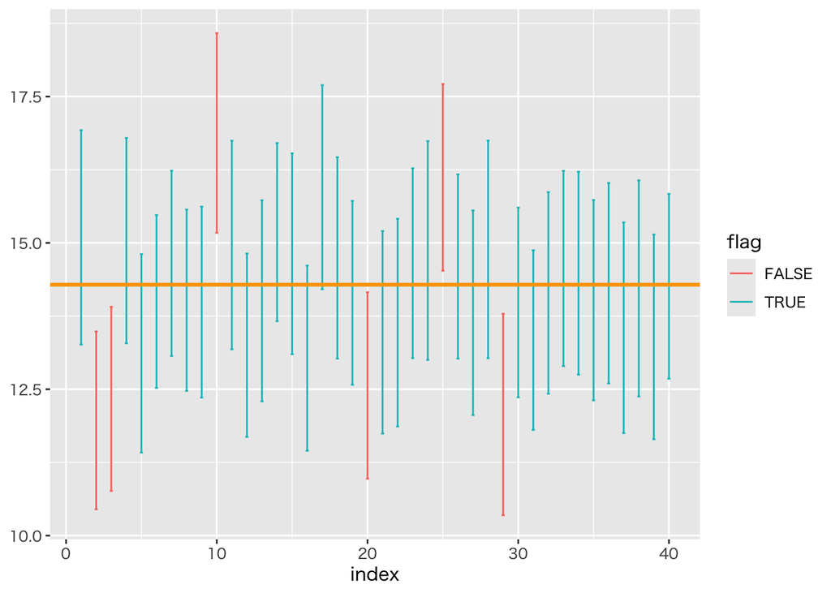

```r
k <- 40
mc_data |>
    slice_sample(n = k) |>            # k個ランダムに選んで描く
    rowid_to_column(var = "index") |> # 抜き出したデータに番号を振る
    mutate(flag = L < mu & mu < U) |> # 区間に真値が含まれるか判別
    ggplot(aes(x = index)) +
    geom_errorbar(aes(ymin = L,       # 下側信頼限界
                      ymax = U,       # 上側信頼限界
                      colour = flag), # 判別結果で色分け
                  width = 0.2) +
    geom_hline(yintercept = mu,       # 観測データを全て使った推定値
               colour = "orange",
               linewidth = 1.1)
```